# YOUTUBE DATA COLLECTION & ANALYSIS

## Objective:

- Let's collect the data about the trending videos on youtube using **"YouTube Data API v3"** to analyze and find what makes a video trend in youtube.
- API Key : AIzaSyAF1ezeJAsWTVQAovXeXsQjdutqjs0vmx4

```python
# Importing necessary libraries
import pandas as pd
from googleapiclient.discovery import build
import warnings
warnings.filterwarnings("ignore")

# API Key
API_KEY = "AIzaSyAF1ezeJAsWTVQAovXeXsQjdutqjs0vmx4"
region = "IN"

def get_video_categories(api_key, region_code = region):
    # Build YouTube service
    youtube = build('youtube', 'v3', developerKey = api_key)

    # Fetching the video categories for the given region
    request = youtube.videoCategories().list(
        part = 'snippet',
        regionCode = region_code
    )
    response = request.execute()

    # Creating a dictionary to map categoryId to categoryName
    categories = {item['id']: item['snippet']['title'] for item in response['items']}

    return categories

def get_trending_videos(api_key, max_results = 200, region_code = region):

    # Build YouTube service
    youtube = build('youtube', 'v3', developerKey = api_key)

    # List to hold video details
    videos = []

    # Fetch video categories
    categories = get_video_categories(api_key, region_code)

    # Fetching the most popular videos
    request = youtube.videos().list(
        part = 'snippet, contentDetails, statistics',
        chart = 'mostPopular',
        regionCode = region_code,
        maxResults = 50
    )

    # Paginate through the results if max_results > 50
    while request and len(videos) < max_results:
        response = request.execute()
        for item in response['items']:
            category_id = item['snippet']['categoryId']
            video_details = {
                'video_id': item['id'],
                'title': item['snippet']['title'],
                'description': item['snippet']['description'],
                'published_at': item['snippet']['publishedAt'],
                'channel_id': item['snippet']['channelId'],
                'channel_title': item['snippet']['channelTitle'],
                'category_id': category_id,
                'category_name': categories.get(category_id, 'Unknown'),
                'tags': item['snippet'].get('tags', []),
                'duration': item['contentDetails']['duration'],
                'definition': item['contentDetails']['definition'],
                'caption': item['contentDetails'].get('caption', 'false'),
                'view_count': item['statistics'].get('viewCount', 0),
                'like_count': item['statistics'].get('likeCount', 0),
                'dislike_count': item['statistics'].get('dislikeCount', 0),
                'favorite_count': item['statistics'].get('favoriteCount', 0),
                'comment_count': item['statistics'].get('commentCount', 0)
            }
            videos.append(video_details)

        # Get the next page token
        request = youtube.videos().list_next(request, response)

    return videos[:max_results]

# Saving collected data
def save_to_csv(data, fileName):
    df = pd.DataFrame(data)
    df.to_csv(fileName, index=False)

def main():
    trending_videos = get_trending_videos(API_KEY)
    fileName = 'trending_videos.csv'
    save_to_csv(trending_videos, fileName)
    print(f'Trending videos saved to {fileName}')

if __name__ == '__main__':
    main()
```

```
Trending videos saved to trending_videos.csv
```

```python
# Loading data
trending_videos = pd.read_csv('trending_videos.csv')
trending_videos.head()
```

|  | video_id | title | description | published_at | channel_id | channel_title | category_id | category_name | tags | duration | definition | caption | view_count | like_count | dislike_count | favorite_count | comment_count |
| --- | --- | --- | --- | --- | --- | --- | --- | --- | --- | --- | --- | --- | --- | --- | --- | --- | --- |
| 0 | MD7v0-igVIM | Singham Again \| Official Trailer \| A Rohit She... | Aa rahi aap ki favourite cop universe aapke sa... | 2024-10-07T07:43:56Z | UCcXQd6kHKm0b41x8zMVMmMg | JioStudios | 24 | Entertainment | ['singham again ajay devgn', 'singam 3 movie',... | PT4M58S | hd | True | 39368574 | 923754 | 0 | 0 | 81201 |
| 1 | 6YMY62tMLUA | Bhool Bhulaiyaa 3 (Official Trailer): Kartik A... | Haveli Ka Darwaza Khula Ek baar Phir… Rooh Bab... | 2024-10-09T09:00:08Z | UCq-Fj5jknLsUf-MWSy4_brA | T-Series | 10 | Music | ['tseries', 'tseries songs', 'bhool bhulaiyaa ... | PT3M51S | hd | True | 54003929 | 1023373 | 0 | 0 | 43707 |
| 2 | KQSEb6ai8Cc | சரஸ்வதி பூஜையில் சரஸ்வதி பாடல் ஒலிக்கும் இடத்த... | அபூர்வா வீடியோஸ் பக்தியுடன் வழங்கும் சரஸ்வதி ப... | 2024-10-10T23:30:05Z | UCIXUddWWVlp7evIeFCMsBZQ | Apoorva Videos | 10 | Music | ['Tamil Songs', 'Tamil Devotional', 'Devotiona... | PT15M46S | hd | False | 183481 | 1550 | 0 | 0 | 65 |
| 3 | 43_TeVV5OsI | 31-year-old Ratan Tata’s closest aide Shantanu... | Ratan Tata, the 86-year-old chairman emeritus ... | 2024-10-10T05:19:41Z | UCtFQDgA8J8_iiwc5-KoAQlg | ANI News | 25 | News & Politics | ['ratan tata death news', 'ratan tata death', ... | PT5M4S | hd | False | 2160806 | 21027 | 0 | 0 | 2619 |
| 4 | YWsQ30gMZ_M | Shantanu Naidu: రతన్ టాటాకు అత్యంత సన్నిహిత మి... | వయసులో 50 ఏళ్లకు పైగా అంతరం ఉన్న వీరిద్దరి స్న... | 2024-10-10T11:52:26Z | UCiTCB-B_weEmwHk7ifNobQw | BBC News Telugu | 25 | News & Politics | ['Ratan Tata', 'Ratan Tata is No more', 'TATA'... | PT4M12S | hd | False | 526916 | 6264 | 0 | 0 | 124 |

```python
import numpy as np
np.shape(trending_videos)
```

```
(137, 17)
```

```python
num_videos = np.shape(trending_videos)[0]

from IPython.display import Markdown
Markdown(f"## Observation:\n- By using the API, we extracted **{num_videos}** trending videos from India.")
```

Observation:

- By using the API, we extracted **137** trending videos from India.

```python
# missing values
trending_videos.isna().sum()
```

```
video_id          0
title             0
description       5
published_at      0
channel_id        0
channel_title     0
category_id       0
category_name     0
tags              0
duration          0
definition        0
caption           0
view_count        0
like_count        0
dislike_count     0
favorite_count    0
comment_count     0
dtype: int64
```

## Observations:

- We can observe that there very less number of null values in description, we can replace it by "Not available"

```python
trending_videos.fillna('Not available', inplace = True)
```

```python
# missing values
trending_videos.isna().sum().sum()
```

```
0
```

```python
# Checking Data Types
trending_videos.info()
```

```
<class 'pandas.core.frame.DataFrame'>
RangeIndex: 137 entries, 0 to 136
Data columns (total 17 columns):
 #   Column          Non-Null Count  Dtype
---  ------          --------------  -----
 0   video_id        137 non-null    object
 1   title           137 non-null    object
 2   description     137 non-null    object
 3   published_at    137 non-null    object
 4   channel_id      137 non-null    object
 5   channel_title   137 non-null    object
 6   category_id     137 non-null    int64
 7   category_name   137 non-null    object
 8   tags            137 non-null    object
 9   duration        137 non-null    object
 10  definition      137 non-null    object
 11  caption         137 non-null    bool
 12  view_count      137 non-null    int64
 13  like_count      137 non-null    int64
 14  dislike_count   137 non-null    int64
 15  favorite_count  137 non-null    int64
 16  comment_count   137 non-null    int64
dtypes: bool(1), int64(6), object(10)
memory usage: 17.4+ KB
```

## Observations:

- We can change the data type of 'published_at' to data time format.

```python
# Converting 'published_at' to data time format
trending_videos['published_at'] = pd.to_datetime(trending_videos['published_at'])
```

```python
trending_videos.info()
```

```
<class 'pandas.core.frame.DataFrame'>
RangeIndex: 137 entries, 0 to 136
Data columns (total 17 columns):
 #   Column          Non-Null Count  Dtype
---  ------          --------------  -----
 0   video_id        137 non-null    object
 1   title           137 non-null    object
 2   description     137 non-null    object
 3   published_at    137 non-null    datetime64[ns, UTC]
 4   channel_id      137 non-null    object
 5   channel_title   137 non-null    object
 6   category_id     137 non-null    int64
 7   category_name   137 non-null    object
 8   tags            137 non-null    object
 9   duration        137 non-null    object
 10  definition      137 non-null    object
 11  caption         137 non-null    bool
 12  view_count      137 non-null    int64
 13  like_count      137 non-null    int64
 14  dislike_count   137 non-null    int64
 15  favorite_count  137 non-null    int64
 16  comment_count   137 non-null    int64
dtypes: bool(1), datetime64[ns, UTC](1), int64(6), object(9)
memory usage: 17.4+ KB
```

```python
trending_videos.head()
```

|  | video_id | title | description | published_at | channel_id | channel_title | category_id | category_name | tags | duration | definition | caption | view_count | like_count | dislike_count | favorite_count | comment_count |
| --- | --- | --- | --- | --- | --- | --- | --- | --- | --- | --- | --- | --- | --- | --- | --- | --- | --- |
| 0 | MD7v0-igVIM | Singham Again \| Official Trailer \| A Rohit She... | Aa rahi aap ki favourite cop universe aapke sa... | 2024-10-07 07:43:56+00:00 | UCcXQd6kHKm0b41x8zMVMmMg | JioStudios | 24 | Entertainment | ['singham again ajay devgn', 'singam 3 movie',... | PT4M58S | hd | True | 39368574 | 923754 | 0 | 0 | 81201 |
| 1 | 6YMY62tMLUA | Bhool Bhulaiyaa 3 (Official Trailer): Kartik A... | Haveli Ka Darwaza Khula Ek baar Phir… Rooh Bab... | 2024-10-09 09:00:08+00:00 | UCq-Fj5jknLsUf-MWSy4_brA | T-Series | 10 | Music | ['tseries', 'tseries songs', 'bhool bhulaiyaa ... | PT3M51S | hd | True | 54003929 | 1023373 | 0 | 0 | 43707 |
| 2 | KQSEb6ai8Cc | சரஸ்வதி பூஜையில் சரஸ்வதி பாடல் ஒலிக்கும் இடத்த... | அபூர்வா வீடியோஸ் பக்தியுடன் வழங்கும் சரஸ்வதி ப... | 2024-10-10 23:30:05+00:00 | UCIXUddWWVlp7evIeFCMsBZQ | Apoorva Videos | 10 | Music | ['Tamil Songs', 'Tamil Devotional', 'Devotiona... | PT15M46S | hd | False | 183481 | 1550 | 0 | 0 | 65 |
| 3 | 43_TeVV5OsI | 31-year-old Ratan Tata’s closest aide Shantanu... | Ratan Tata, the 86-year-old chairman emeritus ... | 2024-10-10 05:19:41+00:00 | UCtFQDgA8J8_iiwc5-KoAQlg | ANI News | 25 | News & Politics | ['ratan tata death news', 'ratan tata death', ... | PT5M4S | hd | False | 2160806 | 21027 | 0 | 0 | 2619 |
| 4 | YWsQ30gMZ_M | Shantanu Naidu: రతన్ టాటాకు అత్యంత సన్నిహిత మి... | వయసులో 50 ఏళ్లకు పైగా అంతరం ఉన్న వీరిద్దరి స్న... | 2024-10-10 11:52:26+00:00 | UCiTCB-B_weEmwHk7ifNobQw | BBC News Telugu | 25 | News & Politics | ['Ratan Tata', 'Ratan Tata is No more', 'TATA'... | PT4M12S | hd | False | 526916 | 6264 | 0 | 0 | 124 |

## Observation:

- We can observe that tags are represented as string of list.
- We can convert it into actual list.

```python
# Converting tags to actual list
trending_videos['tags'] = trending_videos['tags'].apply(lambda x: eval(x) if isinstance(x,str) else x)
```

```python
trending_videos.head()
```

|  | video_id | title | description | published_at | channel_id | channel_title | category_id | category_name | tags | duration | definition | caption | view_count | like_count | dislike_count | favorite_count | comment_count |
| --- | --- | --- | --- | --- | --- | --- | --- | --- | --- | --- | --- | --- | --- | --- | --- | --- | --- |
| 0 | MD7v0-igVIM | Singham Again \| Official Trailer \| A Rohit She... | Aa rahi aap ki favourite cop universe aapke sa... | 2024-10-07 07:43:56+00:00 | UCcXQd6kHKm0b41x8zMVMmMg | JioStudios | 24 | Entertainment | [singham again ajay devgn, singam 3 movie, sin... | PT4M58S | hd | True | 39368574 | 923754 | 0 | 0 | 81201 |
| 1 | 6YMY62tMLUA | Bhool Bhulaiyaa 3 (Official Trailer): Kartik A... | Haveli Ka Darwaza Khula Ek baar Phir… Rooh Bab... | 2024-10-09 09:00:08+00:00 | UCq-Fj5jknLsUf-MWSy4_brA | T-Series | 10 | Music | [tseries, tseries songs, bhool bhulaiyaa 3, bh... | PT3M51S | hd | True | 54003929 | 1023373 | 0 | 0 | 43707 |
| 2 | KQSEb6ai8Cc | சரஸ்வதி பூஜையில் சரஸ்வதி பாடல் ஒலிக்கும் இடத்த... | அபூர்வா வீடியோஸ் பக்தியுடன் வழங்கும் சரஸ்வதி ப... | 2024-10-10 23:30:05+00:00 | UCIXUddWWVlp7evIeFCMsBZQ | Apoorva Videos | 10 | Music | [Tamil Songs, Tamil Devotional, Devotional Son... | PT15M46S | hd | False | 183481 | 1550 | 0 | 0 | 65 |
| 3 | 43_TeVV5OsI | 31-year-old Ratan Tata’s closest aide Shantanu... | Ratan Tata, the 86-year-old chairman emeritus ... | 2024-10-10 05:19:41+00:00 | UCtFQDgA8J8_iiwc5-KoAQlg | ANI News | 25 | News & Politics | [ratan tata death news, ratan tata death, rata... | PT5M4S | hd | False | 2160806 | 21027 | 0 | 0 | 2619 |
| 4 | YWsQ30gMZ_M | Shantanu Naidu: రతన్ టాటాకు అత్యంత సన్నిహిత మి... | వయసులో 50 ఏళ్లకు పైగా అంతరం ఉన్న వీరిద్దరి స్న... | 2024-10-10 11:52:26+00:00 | UCiTCB-B_weEmwHk7ifNobQw | BBC News Telugu | 25 | News & Politics | [Ratan Tata, Ratan Tata is No more, TATA, TCS,... | PT4M12S | hd | False | 526916 | 6264 | 0 | 0 | 124 |

```python
# Categorical and numerical features
numerical_features = []
categorical_features = []
for column in trending_videos.columns :
    if trending_videos[column].dtypes == 'int64':
        numerical_features.append(column)
    else:
        categorical_features.append(column)
```

```python
print(f"Numerical Features: \n{numerical_features}")
print(f"Numerical Features: \n{categorical_features}")
```

```
Numerical Features:
['category_id', 'view_count', 'like_count', 'dislike_count', 'favorite_count', 'comment_count']
Numerical Features:
['video_id', 'title', 'description', 'published_at', 'channel_id', 'channel_title', 'category_name', 'tags', 'duration', 'definition', 'caption']
```

```python
# Descriptive analysis
trending_videos[numerical_features].describe()
```

|  | category_id | view_count | like_count | dislike_count | favorite_count | comment_count |
| --- | --- | --- | --- | --- | --- | --- |
| count | 137.000000 | 1.370000e+02 | 1.370000e+02 | 137.0 | 137.0 | 137.000000 |
| mean | 21.744526 | 2.181493e+06 | 6.325536e+04 | 0.0 | 0.0 | 4306.306569 |
| std | 5.238474 | 6.114401e+06 | 1.425642e+05 | 0.0 | 0.0 | 17526.185900 |
| min | 1.000000 | 4.664100e+04 | 3.690000e+02 | 0.0 | 0.0 | 13.000000 |
| 25% | 22.000000 | 2.547680e+05 | 5.003000e+03 | 0.0 | 0.0 | 137.000000 |
| 50% | 24.000000 | 5.628940e+05 | 1.291600e+04 | 0.0 | 0.0 | 661.000000 |
| 75% | 24.000000 | 1.640395e+06 | 4.681200e+04 | 0.0 | 0.0 | 1862.000000 |
| max | 28.000000 | 5.400393e+07 | 1.023373e+06 | 0.0 | 0.0 | 173962.000000 |

## Observations:

- None of the video got dislikes and none of them are added to favorites.
- Each video got atleast minimum 10 comments.

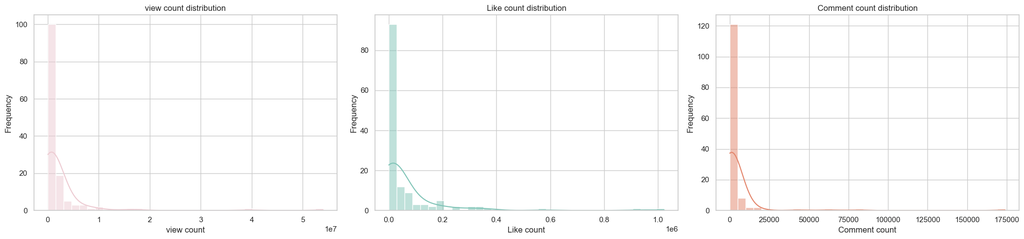

```python
# Distribution view count, like count and comment count
import matplotlib.pyplot as plt
import seaborn as sns
sns.set(style = 'whitegrid')

fig, axes = plt.subplots(1,3, figsize = (21,5))

# View count distribution
sns.histplot(trending_videos['view_count'], bins = 35, kde = True, ax = axes[0], color = "#EDCBD2")
axes[0].set_title("view count distribution")
axes[0].set_xlabel("view count")
axes[0].set_ylabel("Frequency")

# Likes count distribution
sns.histplot(trending_videos['like_count'], bins = 35, kde = True, ax = axes[1], color = "#80C4B7")
axes[1].set_title("Like count distribution")
axes[1].set_xlabel("Like count")
axes[1].set_ylabel("Frequency")

# Comment count distribution
sns.histplot(trending_videos['comment_count'], bins = 35, kde = True, ax = axes[2], color = "#E3856B")
axes[2].set_title("Comment count distribution")
axes[2].set_xlabel("Comment count")
axes[2].set_ylabel("Frequency")

plt.tight_layout()
plt.show()
```